# Homework 9

# Question 2

Once your code is up and working, modify your program to do something else: record a new summary variable, code a new statistical analysis, or create a different set of random variables or output graph. Do not rewrite any of your existing functions. Instead, copy them, rename them, and then modify them to do new things. Once your new functions are written, add some more lines of program code, calling a mixture of your previous functions and your new functions to get the job done.

```r
get_data(rnorm)
```

```
##    len supp dose
## 1  4.2   VC  0.5
## 2 11.5   VC  0.5
## 3  7.3   VC  0.5
## 4  5.8   VC  0.5
## 5  6.4   VC  0.5
## 6 10.0   VC  0.5
```

```
## function (file_name = "ToothGrowth")
## {
##     data("ToothGrowth")
##     head <- head(ToothGrowth)
##     print(head)
##     return(get_data)
## }
## <bytecode: 0x000001de49d45048>
```

```r
PracticeData <- rnorm(50, mean=20, sd=2)
calculate_ANOVA(PracticeData)
```

```
## Call:
##    aov(formula = Pivot$value ~ Pivot$Treatment)
##
## Terms:
##                 Pivot$Treatment Residuals
## Sum of Squares         2213.702  1127.292
## Deg. of Freedom               2        57
##
## Residual standard error: 4.44714
## Estimated effects may be unbalanced
```

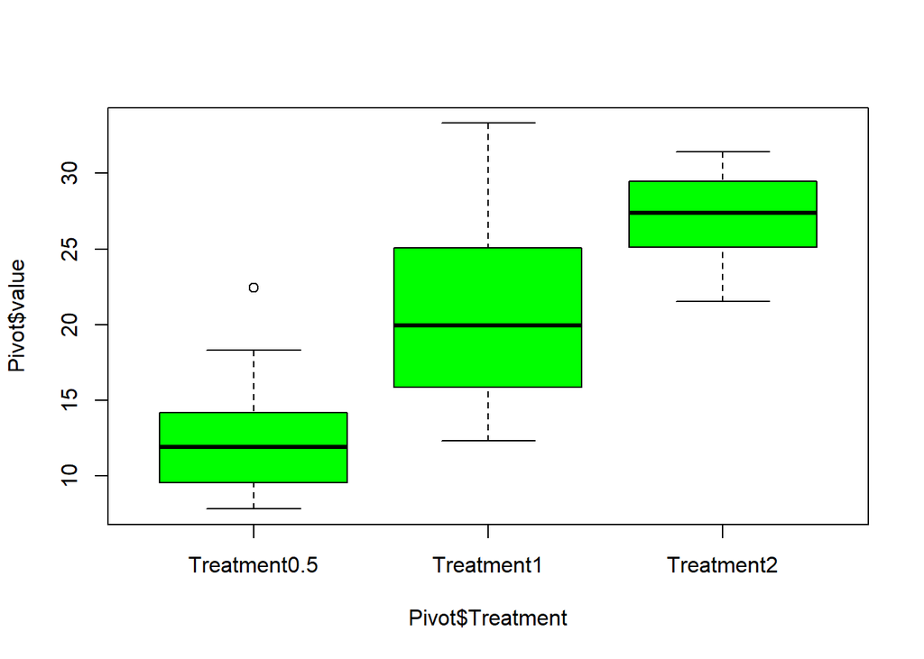

```
## $stats
##           [,1]     [,2]     [,3]
## [1,]  7.795531 12.29006 21.51720
## [2,]  9.527620 15.85871 25.11539
## [3,] 11.896454 19.91916 27.36637
## [4,] 14.187114 25.07300 29.47513
## [5,] 18.284697 33.31828 31.45013
##
## $n
## [1] 20 20 20
##
## $conf
##          [,1]     [,2]     [,3]
## [1,] 10.25026 16.66377 25.82608
## [2,] 13.54265 23.17456 28.90665
##
## $out
## [1] 22.41957
##
## $group
## [1] 1
##
## $names
## [1] "Treatment0.5" "Treatment1"   "Treatment2"
```

```r
create_boxplot2(PracticeData)
```